# coll_wf_data_preparation

**Copyright:**

© 2017-2020, Pavel Sůva, Marek Teller, Martin Kotek, Jan Zeller, Marek Mukenšnabl, Kirill Odintsov, Jan Hynek, Elena Kuchina, Lubor Pacák, Naďa Horká and Home Credit & Finance Bank Limited Liability Company, Moscow, Russia – all rights reserved

Licensed under the Apache License, Version 2.0 (the "License"); you may not use this file except in compliance with the [License](http://www.apache.org/licenses/LICENSE-2.0)

Unless required by applicable law or agreed to in writing, software distributed under the License is distributed on an "AS IS" BASIS, WITHOUT WARRANTIES OR CONDITIONS OF ANY KIND, either express or implied. See the License for the specific language governing permissions and limitations under the License.

For list of contributors see [Gitlab page](https://git.homecredit.net/risk/python-scoring-workflow)

# Import Packages

```python
import time
import datetime
import math
import numpy as np
import pandas as pd
# # import cx_Oracle
import matplotlib
import matplotlib.pyplot as plt
import seaborn as sns
import os.path

import sys
sys.path.insert(0, '..') # path of scoring workflow folder
import scoring
from scoring import db
```

Set general technical parameters and paths.

```python
sns.set()
%matplotlib inline
%config InlineBackend.close_figures=True
from IPython.display import display, Markdown
pd.options.display.max_columns = None
pd.options.display.max_rows = 15
output_folder = 'documentation_preparation_demo'

if not os.path.exists(output_folder): os.makedirs(output_folder)
if not os.path.exists(output_folder+'/analysis'): os.makedirs(output_folder+'/analysis')
if not os.path.exists(output_folder+'/datasets'): os.makedirs(output_folder+'/datasets')

scoring.check_version('0.8.0', list_versions=True)
```

**WARNING**:  
Your pandas module is version 1.0.1. PSW requires exactly 0.25.3

```
Module               Version
numpy                1.18.1
scipy                1.4.1
pandas               1.0.1
sklearn              0.22.1
statsmodels          0.11.0
matplotlib           3.1.3
seaborn              0.10.0
sqlalchemy           1.3.13
cx_Oracle            7.2.3
ipywidgets           7.5.1
packaging            20.1
qgrid                1.1.1
tqdm                 4.42.1
xgboost              1.1.0
lightgbm             2.3.0
shap                 0.35.0
hyperopt             0.2.3
```

# Data import

Importing data from a CSV file. It is important to set the following parameters:

encoding: usually 'utf-8' or windows-xxxx on Windows machines, where xxxx is 1250 for Central Europe, 1251 for Cyrilic etc. sep: separator of columns in the file decimal: decimal dot or coma index_col: which columns is used as index - should be the unique credit case identifier

```python
data = db.read_csv(r'coll_demo_data\demo_dataset.csv',
                      sep = ',', decimal = '.', optimize_types=True,
                      encoding = 'utf-8', low_memory = False)

print('Data loaded on',datetime.datetime.fromtimestamp(time.time()).strftime('%Y-%m-%d %H:%M:%S'))
print()
print('Number of rows: {:15.0f}'.format(data.shape[0]))
print('Number of columns: {:12.0f}'.format(data.shape[1]))
```

```
Data loaded on 2020-07-09 10:57:38

Number of rows:          136921
Number of columns:           37
```

```python
data.info()
```

```
<class 'pandas.core.frame.DataFrame'>
RangeIndex: 136921 entries, 0 to 136920
Data columns (total 37 columns):
 #   Column                    Non-Null Count   Dtype
---  ------                    --------------   -----
 0   STARTDATE                 136921 non-null  category
 1   PAIDDATE                  135881 non-null  category
 2   PROCESS_NAME              136921 non-null  category
 3   AGECLIENT                 136921 non-null  uint8
 4   AMTBALANCEACTUALCONTRACT  136921 non-null  float64
 5   AMTBALPRINCMAXHISTCONTR   136921 non-null  float64
 6   AMTCREDIT                 136921 non-null  float64
 7   AMTINCOMEHOUSEHOLD        1389 non-null    float64
 8   AMTINCOMEMAINOCCUPATION   136109 non-null  float64
 9   AMTINSTALMENT             136921 non-null  float64
```

[output cut: 29 more lines]

## Metadata Definition

```python
### THESE COLUMNS MUST BE INCLUDED IN THE DATA SET ###

# name of your target column in your dataset
col_target_orig = "TARGET_DPD"
col_target_z = 'TARGET_Z'
# name of the time column in your dataset
col_time = "STARTDATE"
col_diff_days = "DAYS_DIFF"
# name of the workflow column - usually Low, High, Medium etc.
col_workflow = 'PROCESS_NAME'
col_treatment = 'HIGHER_TREATMENT'
# name of the product column - e.g. CASH/CONSUMER
col_product = 'TYPEOFCREDIT'


### THESE COLUMNS DON'T HAVE TO BE INCLUDED IN THE DATA SET AND ARE CREATED AUTOMATICALLY LATER with this given name ###
#name of the base column
col_base = "BASE"
# name of the year column
col_year = "YEAR"
# name of the month column
col_month = "MONTH"
# name of the day column
col_day = "DAY"
# name of the year and week column
col_week = "WEEK"



col_instalment = 'AMTINSTALMENT'
col_receivable = 'AMT_RECEIVABLE'


# #name of the weight column
col_weight = 'WEIGHT'
```

```python
# DECIDE WHICH TIME UNIT YOU WANT TO USE AS DEFAULT FOR THIS EXPLORATORY ANALYSIS - A WEEK OR A MONTH?

time_unit = col_month
```

Create the month and day column from the time column is doing the following

- take the time column and tell in which format the time is saved in - **you need to specify this in variable *dtime_input_format*** (see https://docs.python.org/3/library/time.html#time.strftime for reference)
- strip the format just to year, month, day string
- convert the string to number
- the new column will be added to the dataset as day
- truncate this column to just year and month and add it to dataset as month
- add the week to the dataset

```python
dtime_input_format = '%Y-%m-%d'
```

```python
data.loc[:,col_day] = pd.to_numeric(pd.to_datetime(data[col_time], format=dtime_input_format, cache=False).dt.strftime('%Y%m%d'))
data[col_month] = data[col_day].apply(lambda x: math.trunc(x/100))
data[col_year] = data[col_day].apply(lambda x: math.trunc(x/10000))

data[col_time]=pd.to_datetime(data[col_time], format=dtime_input_format, cache=False)

data[col_week] =data[col_year]*100 + data[col_time].dt.week

print('Columns',col_day,',',col_month,'and',col_week,'added/modified. Number of columns:',data.shape[1])
```

```
Columns DAY , MONTH and WEEK added/modified. Number of columns: 41
```

```python
data.head()
```

|  | STARTDATE | PAIDDATE | PROCESS_NAME | AGECLIENT | AMTBALANCEACTUALCONTRACT | AMTBALPRINCMAXHISTCONTR | AMTCREDIT | AMTINCOMEHOUSEHOLD | AMTINCOMEMAINOCCUPATION | AMTINSTALMENT | AMTINSTALMENTPENALTY | AMTINSTALMENTTOTAL | AMT_RECEIVABLE | BROKENRATECONTRACT | CNTCYCLESCONTRACT | CNTDAYSFRMLCYCLECONTRACT | CNTDAYSLSTPMTCONTRACT | CNTDPDMAXHISTCONTRACT | CNTFIRSTDLQINSCONTRACT | CNTINBOUNDCALL | CNTMAXDPD1MCONTRACT | CNTMAXDPD3MCONTRACT | CODEREGIONCLIENT | DAYSSINCELSTRPCCONTRACT | EDUCATIONLEVELCLIENT | FAMILYSTATUSCLIENT | GENDERCLIENT | MOBCONTRACT | OCCUPATIONINDUSTRYCLIENT | … |
| --- | --- | --- | --- | --- | --- | --- | --- | --- | --- | --- | --- | --- | --- | --- | --- | --- | --- | --- | --- | --- | --- | --- | --- | --- | --- | --- | --- | --- | --- | --- |
| 0 | 2018-11-09 | 2018-11-09 | HIGH | 40 | 3.04 | 470.2264 | 7849.800 | NaN | 150000.0 | 13463.80952 | 341.0 | 254848.00 | 56458.00 | 0.67 | 12 | 31 | 31 | 6 | 2.0 | 0 | 1 | 2 | 16.0 | 7.0 | Student | Married | M | 15 | Type_2 | … |
| 1 | 2018-11-15 | 2018-11-15 | LOW | 66 | 0.00 | 733.6300 | 16552.494 | NaN | 290000.0 | 29080.95238 | 0.0 | 543732.78 | 396906.00 | 1.00 | 1 | 31 | 31 | 1 | 5.0 | 1 | 1 | 1 | 7.0 | 7.0 | Student | Married | M | 6 | Type_3 | … |
| 2 | 2020-02-02 | 2020-02-04 | HIGH | 41 | 628.64 | 0.0000 | 7992.096 | NaN | 250000.0 | 15102.85714 | 0.0 | 190288.00 | 174288.00 | 1.00 | 0 | 0 | 45 | 0 | 2.0 | 1 | 1 | 1 | 16.0 | 5.0 | Student | Married | M | 2 | Type_6 | … |
| 3 | 2019-04-27 | 2019-05-05 | HIGH | 26 | 425.92 | 0.0000 | 4321.380 | NaN | 350000.0 | 10140.95238 | 0.0 | 135077.51 | 127756.00 | NaN | 0 | 0 | 0 | 0 | 1.0 | 1 | 1 | 1 | 1.0 | 30.0 | Student | Married | M | 1 | Type_6 | … |
| 4 | 2019-08-05 | 2019-08-06 | HIGH | 32 | 740.96 | 0.0000 | 3569.580 | NaN | 200000.0 | 17641.90476 | 0.0 | 405303.85 | 129548.76 | NaN | 0 | 0 | 33 | 0 | 3.0 | 1 | 1 | 1 | 4.0 | 120.0 | Student | Married | M | 3 | Type_6 | … |

## Target Definition

Use if you have the target not decided yet. The target is defined as 'delinquent in target-DPD'.

To be able to use the script, your data have to contain

- The date of the payment
- The date difference between entry date and payment date

```python
# Computing he date difference between entry date and payment date
data[[col_time,'PAIDDATE']] = data[[col_time,'PAIDDATE']].apply(pd.to_datetime, format=dtime_input_format, cache=False)
data[col_diff_days] = (data['PAIDDATE'] - data[col_time]).dt.days
```

```python
data.loc[data['PAIDDATE'].isna(), 'DAYS_DIFF'] = 30
```

```python
data[(data[col_time] > datetime.datetime.strptime('2020-03-10', '%Y-%m-%d')) & (data['PAIDDATE'].isna())].index
```

```
Int64Index([], dtype='int64')
```

Delete rows with target date in future (for the time of the dataset download)

```python
data.drop(data[(data[col_time] > datetime.datetime.strptime('2020-03-10', '%Y-%m-%d')) & \
               (data['PAIDDATE'].isna())].index, inplace=True)
```

```python
data_unfinished = data[data['PAIDDATE'].isna()]

print((datetime.datetime.strptime('2020-03-13', '%Y-%m-%d') - data_unfinished[col_time]).dt.days)
```

```
493       11
554        7
986        6
1053       4
1205      17
          ..
136600     8
136620    17
136810     3
136828    19
136883     8
Name: STARTDATE, Length: 1040, dtype: int64
```

```python
data.loc[data['DAYS_DIFF'] > 30, 'DAYS_DIFF'] = 30
```

```python
days = pd.DataFrame(data[[col_diff_days, col_workflow, 'AMTBALANCEACTUALCONTRACT']].groupby([col_diff_days, col_workflow]).sum())
days.sort_index(inplace=True)

days_cum = days.groupby(col_workflow).cumsum()
days_cum.reset_index(level = col_workflow, inplace=True)
days_cum = days_cum.pivot(columns=col_workflow, values='AMTBALANCEACTUALCONTRACT')
maxim = days_cum.max()
days_pct = days_cum/maxim
# display(days_pct)
days_pct_diff = (days_pct['HIGH'] - days_pct['LOW'])*100
# display(days_pct_diff)
```

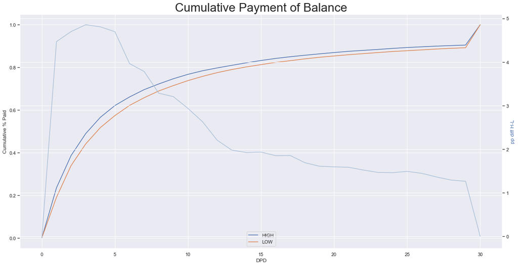

```python
plt.figure(figsize = (20, 10))
fig, ax1 = plt.subplots(figsize=(20,10))

ax2 = ax1.twinx()
ax1.plot(days_pct)
ax2.plot(days_pct_diff, 'xkcd:cloudy blue')

plt.title('Cumulative Payment of Balance', fontsize=28)
ax1.set_xlabel('DPD')
ax1.set_ylabel('Cumulative % Paid')
ax1.legend(days_pct.columns, loc='lower center')
# ax2.legend('diff H-L')
ax2.set_ylabel('pp diff H-L', color='b')

filepath = os.path.join(output_folder, 'analysis', 'payment_curve.png')
plt.savefig(filepath, format='png', bbox_inches='tight')
plt.show()
```

**Decision of the target**

```python
col_target_orig = 'TARGET_10D'

data[col_target_orig] = 1
data.loc[(data[col_diff_days]<= 10), col_target_orig] = 0
```

```python
if col_base not in data:
    data[col_base] = 0
    data.loc[data[col_target_orig]==0,col_base] = 1
    data.loc[data[col_target_orig]==1,col_base] = 1
    print('Column',col_base,'added/modified. Number of columns:',data.shape[1])
else:
    print('Column',col_base,'already exists.')
```

```
Column BASE added/modified. Number of columns: 44
```

# Data Cleaning

The most important part of preparation of data is to carefully check the values (explore_df, explore_numerical and explore_categorical is here to help you) and decide which attributes or which rows you will or will not use. Some attributes are crucial for calculating the CAASB (amount receivable and amount of instalment) and thus you cannot calculate CAASB for rows with missing values for them.

You can decide for cleaning the data - e.g. deleting the rows which miss important information or deleting the columns with predictor which does have not-null value in only 5 % of rows etc.

You can refer to the Segmentation Cookbook https://wiki.homecredit.net/confluence/display/RSK/Segmentation+Cookbook

## Installment and Receivable

Here, only rows with null in amount of instalment are deleted from the data

```python
#
rownr_0 = data.shape[0]
print('Original number of rows: ', rownr_0)

data = data[data[col_instalment].notna()]

rownr_1 = data.shape[0]
print('New number of rows: ', rownr_1)
print('Number of rows deleted: ', rownr_0 - rownr_1)
```

```
Original number of rows:  136921
New number of rows:  136921
Number of rows deleted:  0
```

here, only rows with null in amount of receivable are deleted from the data

```python
rownr_0 = data.shape[0]
print('Original number of rows: ', rownr_0)

data = data[data[col_receivable].notna()]

rownr_1 = data.shape[0]
print('New number of rows: ', rownr_1)
print('Number of rows deleted: ', rownr_0 - rownr_1)
```

```
Original number of rows:  136921
New number of rows:  136921
Number of rows deleted:  0
```

## Too Many Missing Values

```python
from scoring.data_exploration import metadata_table
```

```python
meta_table = metadata_table(data)
```

```python
min_fill_percentage = 5
```

```python
low_perc = pd.DataFrame(columns=meta_table.columns)
for i,j in np.array(meta_table[['name','fill pct']]):
    if j < min_fill_percentage:
        low_perc = low_perc.append(meta_table[meta_table['name'] == i])
display(low_perc)
```

|  | name | type | nunique | value examples | fill pct |
| --- | --- | --- | --- | --- | --- |
| 7 | AMTINCOMEHOUSEHOLD | float64 | 192 | nan, 4000.0, 7920.0, 8600.0, 9000.0, 10000.0, ... | 1.014454 |

# Dataset Splits

## Splitting the Dataset into Products

Creating the masks for different products.

```python
products = data[col_product].unique()

print(products)
```

```
[CEL, REL]
Categories (2, object): [CEL, REL]
```

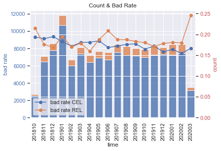

```python
from scoring.plot import plot_dataset

# time_unit = col_month # use if you want to see different time interval

plot_dataset(
    data,
    month_col=time_unit,
    def_col=col_target_orig,
    base_col=col_base,
    segment_col=col_product,
    output_folder=os.path.join(output_folder, "analysis"),
    filename="bad_rate_plot.png",
#     weight_col=col_weight,
    zero_ylim=True,
)

# time_unit = col_week # use if you want to set the interval back
```

## Splitting the Dataset into Workflows

Creating the masks for different workflows.

**Get to know your workflows - which do we have in the dataset?**

```python
workflows = data[col_workflow].unique()

print(workflows)
```

```
[HIGH, LOW]
Categories (2, object): [HIGH, LOW]
```

**Higher treatment workflow definition**

For obtaining the uplift graphs, we have to specify, which treatment is the 'more intensive treatment' and mark it as higher_treatment = 1. The less intensive is higher_treatment = 0.

```python
data[col_treatment] = 0
data.loc[data['PROCESS_NAME'] == 'HIGH', col_treatment] = 1
```

**Default Rate in Time**

Simple visualization of the counts and bad rates for each workflow defined in data

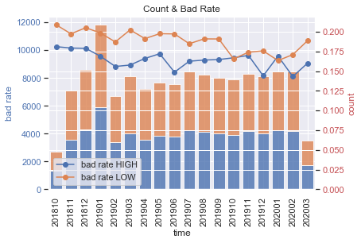

```python
# from scoring.plot import plot_dataset

# time_unit = col_week # use if you want to see different time interval

plot_dataset(
    data,
    month_col=time_unit,
    def_col=col_target_orig,
    base_col=col_base,
    segment_col=col_workflow,
    output_folder=os.path.join(output_folder, "analysis"),
    filename="bad_rate_plot_wf.png",
    #     weight_col=col_weight,
    zero_ylim=True,
    )


# time_unit = col_month # use if you want to set the interval back
```

## Target Variable Transformation

The Jaroszewicz's transformation is creating a new Target Variable in a very simple manner.

Z = 1 if treatment = High and original target = 0  
Z = 1 if treatment = Low and original target = 1  
Z = 0 ... otherwise

If you are interested in the background, please check this [link](http://people.cs.pitt.edu/~milos/icml_clinicaldata_2012/Papers/Oral_Jaroszewitz_ICML_Clinical_2012.pdf)

**Please be aware** that since our target is defined as 1 == client did not pay, 0 == client paid, some of the definitions from this paper had to be flipped to comply to our needs.

```python
# TARGET TRANSFORMATION
data[col_target_z] = 0
data.loc[(data[col_target_orig]==0) & (data[col_treatment] == 1),col_target_z] = 1
data.loc[(data[col_target_orig]==1) & (data[col_treatment] == 0),col_target_z] = 1
```

```python
data.head()
```

|  | STARTDATE | PAIDDATE | PROCESS_NAME | AGECLIENT | AMTBALANCEACTUALCONTRACT | AMTBALPRINCMAXHISTCONTR | AMTCREDIT | AMTINCOMEHOUSEHOLD | AMTINCOMEMAINOCCUPATION | AMTINSTALMENT | AMTINSTALMENTPENALTY | AMTINSTALMENTTOTAL | AMT_RECEIVABLE | BROKENRATECONTRACT | CNTCYCLESCONTRACT | CNTDAYSFRMLCYCLECONTRACT | CNTDAYSLSTPMTCONTRACT | CNTDPDMAXHISTCONTRACT | CNTFIRSTDLQINSCONTRACT | CNTINBOUNDCALL | CNTMAXDPD1MCONTRACT | CNTMAXDPD3MCONTRACT | CODEREGIONCLIENT | DAYSSINCELSTRPCCONTRACT | EDUCATIONLEVELCLIENT | FAMILYSTATUSCLIENT | GENDERCLIENT | MOBCONTRACT | OCCUPATIONINDUSTRYCLIENT | … |
| --- | --- | --- | --- | --- | --- | --- | --- | --- | --- | --- | --- | --- | --- | --- | --- | --- | --- | --- | --- | --- | --- | --- | --- | --- | --- | --- | --- | --- | --- | --- |
| 0 | 2018-11-09 | 2018-11-09 | HIGH | 40 | 3.04 | 470.2264 | 7849.800 | NaN | 150000.0 | 13463.80952 | 341.0 | 254848.00 | 56458.00 | 0.67 | 12 | 31 | 31 | 6 | 2.0 | 0 | 1 | 2 | 16.0 | 7.0 | Student | Married | M | 15 | Type_2 | … |
| 1 | 2018-11-15 | 2018-11-15 | LOW | 66 | 0.00 | 733.6300 | 16552.494 | NaN | 290000.0 | 29080.95238 | 0.0 | 543732.78 | 396906.00 | 1.00 | 1 | 31 | 31 | 1 | 5.0 | 1 | 1 | 1 | 7.0 | 7.0 | Student | Married | M | 6 | Type_3 | … |
| 2 | 2020-02-02 | 2020-02-04 | HIGH | 41 | 628.64 | 0.0000 | 7992.096 | NaN | 250000.0 | 15102.85714 | 0.0 | 190288.00 | 174288.00 | 1.00 | 0 | 0 | 45 | 0 | 2.0 | 1 | 1 | 1 | 16.0 | 5.0 | Student | Married | M | 2 | Type_6 | … |
| 3 | 2019-04-27 | 2019-05-05 | HIGH | 26 | 425.92 | 0.0000 | 4321.380 | NaN | 350000.0 | 10140.95238 | 0.0 | 135077.51 | 127756.00 | NaN | 0 | 0 | 0 | 0 | 1.0 | 1 | 1 | 1 | 1.0 | 30.0 | Student | Married | M | 1 | Type_6 | … |
| 4 | 2019-08-05 | 2019-08-06 | HIGH | 32 | 740.96 | 0.0000 | 3569.580 | NaN | 200000.0 | 17641.90476 | 0.0 | 405303.85 | 129548.76 | NaN | 0 | 0 | 33 | 0 | 3.0 | 1 | 1 | 1 | 4.0 | 120.0 | Student | Married | M | 3 | Type_6 | … |

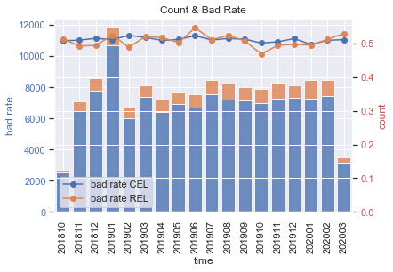

```python
# from scoring.plot import plot_dataset

# time_unit = col_week # use if you want to see different time interval
plot_dataset(
    data,
    month_col=time_unit,
    def_col=col_target_z,
    base_col=col_base,
    segment_col=col_product,
    output_folder=os.path.join(output_folder, "analysis"),
    filename="bad_rate_product_z.png",
    #     weight_col=col_weight,
    zero_ylim=True,
    )

# time_unit = col_month # use if you want to set the interval back
```

### Weights for the Transformed Target

For the one model transformation, it is needed to have the ratio of classifiables in higher and lower treatment = 1:1, thus, the probability

**P(group == higher treatment) = P(group == lower treatment) = 1/2**

If not, we may reweight or resample the training dataset such that the assumption becomes valid.

```python
def make_balanced(df, balancing_var, weight_col, group_name=None, group=None):

        if group:
            df = df[df[group_name] == group]
        else:
            pass

        B = df[balancing_var].value_counts().values/df[balancing_var].value_counts().values.sum()
        max_PD = B.max()
        B = max_PD/B
        A = df[balancing_var].value_counts().index

        C = pd.DataFrame(B,A)
        C = C.reset_index(drop = False)
        C.rename( columns = {'index' : balancing_var,  0 : weight_col}, inplace = True)

        df =  pd.merge(df, C , how = 'left', left_on=balancing_var, right_on=balancing_var)

        print(C)
        return df
```

**Choose which groups to balance**

```python
balance_group = 'all'  # col_product, col_name


if balance_group == 'all':
    if col_weight in (data.columns):
        data.drop(columns=col_weight, inplace=True)
        print('column ' + col_weight + ' dropped')
    data = make_balanced(data, col_treatment, col_weight)

else:
    balance_group_lst = data[balance_group].unique()
    data_product = list()
    for i in range(len(balance_group_lst)):
        data_product.append(make_balanced(data, col_treatment, 'WEIGHT_BY_'+ balance_group, group_name=balance_group, group=balance_group_lst[i]))
```

```
   HIGHER_TREATMENT    WEIGHT
0                 0  1.000000
1                 1  1.006668
```

# Export Datasets for the Main Python Scoring Workflow (PSW)

Here, you can create various types of datasets ready to use in the PSW:

- Distinct workflows' datasets for two-model segmentation
- Distinct products' datasets for one-model transformed segmentation for distinct products (e.g. POS, CARDs, CLX, ...)
- Combination of workflows and products for two-model segmentation for distinct products

## One Workflow for One-model with Transformed Target Z

```python
savepath = os.path.join(output_folder,"datasets",'dataset_z.csv')
data.to_csv(savepath, encoding='utf-8', index=False)
```

## Distinct Workflows' Datasets for Two-model Segmentation

```python
for i in range(len(workflows)):
    savepath = os.path.join(output_folder,"datasets",'dataset_' + workflows[i] + '.csv')
    data[data[col_workflow] == workflows[i]].to_csv(savepath, encoding='utf-8', index=False)

# data.to_csv('prep2_df_all.csv', encoding='utf-8', index=False)
```

## Distinct Products' Datasets for One-model Segmentation

```python
for i in range (len(products)):
    savepath = os.path.join(output_folder,"datasets",'dataset_z_' + products[i] + '.csv')
    data_product[i].to_csv(savepath, encoding='utf-8', index=False)
```

[output not shown]

## Combinations

```python
for i in range (len(products)):
    for j in range (0,len(workflows)):
        savepath = os.path.join(output_folder,"datasets",'dataset_' + products[i] + '_' + workflows[j] + '.csv')
        data[(data[col_product] == products[i]) & (data[col_workflow] == workflows[j])]\
        .to_csv(savepath, encoding='utf-8', index=False)
```